# seed_markdown

2025-07-07

## Project overview

The purpose of this project was to use multiple methods of classification and clustering

## Code Walk Through

The .txt file of the “Seeds” dataset was read into R. The .txt file did not contain column names, so the variable names were entered from the information provided on the UC Irvine Machine Learning Repository. According to the dataset description, the data is made up of seeds of three different types of wheat, Kama, Rosa and Canadian, with 70 entries for each type, for the purpose of clustering analysis. The data contains 210 rows and 7 columns. (The original data contained an additional column that identified the cluster, and this column was dropped). All the columns are continuous quantitative ratio variables that are measurements of characteristics of seeds. The variables are Area, Perimeter, Compactness, Length of Kernel, Width of Kernel, Asymmetry Coefficient, Length of Kernel Groove. The data is complete with no missing values (Figure 1).

## Prepare the environment

```r
# prepare the environment
cat("\014") # clears console
```

```r
rm(list = ls()) # clears global environment
try(dev.off(dev.list()["RStudioGD"]), silent = TRUE) # clears plots
try(p_unload(p_loaded(), character.only = TRUE), silent = TRUE) # clears packages
options(scipen = 100) # disables scientific notion for entire R session
```

## set seed

```r
set.seed(123)
```

## read txt file into environment

```r
data <- read.table("seeds_dataset.txt", header = FALSE)
```

## Prepare the data

```r
## rename columns with variables names
colnames(data) <- c("Area", "Perimeter", "Compactness", "length_of_kernel",
        "width_of_kernel", "asymmetry_coefficient", "length_of_kernel_groove")
head(data)
```

```
##    Area Perimeter Compactness length_of_kernel width_of_kernel
## 1 15.26     14.84      0.8710            5.763           3.312
## 2 14.88     14.57      0.8811            5.554           3.333
## 3 14.29     14.09      0.9050            5.291           3.337
## 4 13.84     13.94      0.8955            5.324           3.379
## 5 16.14     14.99      0.9034            5.658           3.562
## 6 14.38     14.21      0.8951            5.386           3.312
##   asymmetry_coefficient length_of_kernel_groove NA
## 1                 2.221                   5.220  1
## 2                 1.018                   4.956  1
## 3                 2.699                   4.825  1
## 4                 2.259                   4.805  1
## 5                 1.355                   5.175  1
## 6                 2.462                   4.956  1
```

```r
# list number of rows, columns, and structure of the data
nrow(data)
```

```
## [1] 210
```

```r
ncol(data)
```

```
## [1] 8
```

```r
str(data)
```

```
## 'data.frame':    210 obs. of  8 variables:
##  $ Area                   : num  15.3 14.9 14.3 13.8 16.1 ...
##  $ Perimeter              : num  14.8 14.6 14.1 13.9 15 ...
##  $ Compactness            : num  0.871 0.881 0.905 0.895 0.903 ...
##  $ length_of_kernel       : num  5.76 5.55 5.29 5.32 5.66 ...
##  $ width_of_kernel        : num  3.31 3.33 3.34 3.38 3.56 ...
##  $ asymmetry_coefficient  : num  2.22 1.02 2.7 2.26 1.35 ...
##  $ length_of_kernel_groove: num  5.22 4.96 4.83 4.8 5.17 ...
##  $ NA                     : int  1 1 1 1 1 1 1 1 1 1 ...
```

```r
# drop column 8 (it identifies the seed group)
data <- data[-8]
```

## data summary

The data contains 210 rows and 7 columns. (The original data contained an additional column that identified the cluster, and this column was dropped). All the columns are continuous quantitative ratio variables that are measurements of characteristics of seeds. The variables are Area, Perimeter, Compactness, Length of Kernel, Width of Kernel, Asymmetry Coefficient, Length of Kernel Groove. The data is complete with no missing values.

```r
## data summary with skim and psych describe
skim(data)
```

Data summary

| Name | data |
| --- | --- |
| Number of rows | 210 |
| Number of columns | 7 |
| _______________________ |  |
| Column type frequency: |  |
| numeric | 7 |
| ________________________ |  |
| Group variables | None |

**Variable type: numeric**

| skim_variable | n_missing | complete_rate | mean | sd | p0 | p25 | p50 | p75 | p100 | hist |
| --- | --- | --- | --- | --- | --- | --- | --- | --- | --- | --- |
| Area | 0 | 1 | 14.85 | 2.91 | 10.59 | 12.27 | 14.36 | 17.30 | 21.18 | ▇▆▅▅▂ |
| Perimeter | 0 | 1 | 14.56 | 1.31 | 12.41 | 13.45 | 14.32 | 15.71 | 17.25 | ▆▇▆▅▅ |
| Compactness | 0 | 1 | 0.87 | 0.02 | 0.81 | 0.86 | 0.87 | 0.89 | 0.92 | ▂▃▇▇▃ |
| length_of_kernel | 0 | 1 | 5.63 | 0.44 | 4.90 | 5.26 | 5.52 | 5.98 | 6.68 | ▆▇▅▅▂ |
| width_of_kernel | 0 | 1 | 3.26 | 0.38 | 2.63 | 2.94 | 3.24 | 3.56 | 4.03 | ▇▇▇▆▅ |
| asymmetry_coefficient | 0 | 1 | 3.70 | 1.50 | 0.77 | 2.56 | 3.60 | 4.77 | 8.46 | ▆▇▇▂▁ |
| length_of_kernel_groove | 0 | 1 | 5.41 | 0.49 | 4.52 | 5.04 | 5.22 | 5.88 | 6.55 | ▂▇▂▃▂ |

```r
psych::describe(data)
```

```
##                         vars   n  mean   sd median trimmed  mad   min   max
## Area                       1 210 14.85 2.91  14.36   14.70 3.34 10.59 21.18
## Perimeter                  2 210 14.56 1.31  14.32   14.49 1.49 12.41 17.25
## Compactness                3 210  0.87 0.02   0.87    0.87 0.02  0.81  0.92
## length_of_kernel           4 210  5.63 0.44   5.52    5.60 0.48  4.90  6.68
## width_of_kernel            5 210  3.26 0.38   3.24    3.25 0.47  2.63  4.03
## asymmetry_coefficient      6 210  3.70 1.50   3.60    3.64 1.67  0.77  8.46
## length_of_kernel_groove    7 210  5.41 0.49   5.22    5.38 0.39  4.52  6.55
##                         range  skew kurtosis   se
## Area                    10.59  0.39    -1.11 0.20
## Perimeter                4.84  0.38    -1.13 0.09
## Compactness              0.11 -0.53    -0.19 0.00
## length_of_kernel         1.78  0.52    -0.82 0.03
## width_of_kernel          1.40  0.13    -1.12 0.03
## asymmetry_coefficient    7.69  0.40    -0.12 0.10
## length_of_kernel_groove  2.03  0.55    -0.87 0.03
```

## Standardize the Data using scale()

After initial analysis of the data, the next step was to standardize the data using the scale() function. Standardizing the data is critical because it prevents variables with larger scales (like Area, which ranges from 10.6 to 21.2) from having a greater influence over the cluster than variables with smaller scales (such as Compactness, which ranges from 0.808 to 0.918). As shown in Figure 2, after standardization using the scale() function, the mean of all variables is near 0, and the standard deviation of all variables is 1. This was achieved by subtracting the mean and dividing by the standard deviation.

```r
data2<-scale(data)
head(data2)
```

```
##             Area    Perimeter   Compactness length_of_kernel width_of_kernel
## [1,]  0.14175904  0.214948819 0.00006045733       0.30349301       0.1413640
## [2,]  0.01116136  0.008204153 0.42749377817      -0.16822270       0.1969616
## [3,] -0.19160873 -0.359341919 1.43894490373      -0.76181710       0.2075516
## [4,] -0.34626388 -0.474200066 1.03690366135      -0.68733567       0.3187467
## [5,]  0.44419577  0.329806966 1.37123269449       0.06650665       0.8032397
## [6,] -0.16067770 -0.267455401 1.01997560904      -0.54740087       0.1413640
##      asymmetry_coefficient length_of_kernel_groove
## [1,]            -0.9838010              -0.3826631
## [2,]            -1.7839036              -0.9198156
## [3,]            -0.6658882              -1.1863572
## [4,]            -0.9585276              -1.2270506
## [5,]            -1.5597684              -0.4742231
## [6,]            -0.8235144              -0.9198156
```

```r
# data summary of standardized data
skim(data2)
```

Data summary

| Name | data2 |
| --- | --- |
| Number of rows | 210 |
| Number of columns | 7 |
| _______________________ |  |
| Column type frequency: |  |
| numeric | 7 |
| ________________________ |  |
| Group variables | None |

**Variable type: numeric**

| skim_variable | n_missing | complete_rate | mean | sd | p0 | p25 | p50 | p75 | p100 | hist |
| --- | --- | --- | --- | --- | --- | --- | --- | --- | --- | --- |
| Area | 0 | 1 | 0 | 1 | -1.46 | -0.89 | -0.17 | 0.84 | 2.18 | ▇▆▅▅▂ |
| Perimeter | 0 | 1 | 0 | 1 | -1.65 | -0.85 | -0.18 | 0.88 | 2.06 | ▆▇▆▅▅ |
| Compactness | 0 | 1 | 0 | 1 | -2.66 | -0.60 | 0.10 | 0.71 | 2.00 | ▂▃▇▇▃ |
| length_of_kernel | 0 | 1 | 0 | 1 | -1.65 | -0.83 | -0.24 | 0.79 | 2.36 | ▆▇▅▅▂ |
| width_of_kernel | 0 | 1 | 0 | 1 | -1.66 | -0.83 | -0.06 | 0.80 | 2.05 | ▇▇▇▆▅ |
| asymmetry_coefficient | 0 | 1 | 0 | 1 | -1.95 | -0.76 | -0.07 | 0.71 | 3.16 | ▆▇▇▂▁ |
| length_of_kernel_groove | 0 | 1 | 0 | 1 | -1.81 | -0.74 | -0.38 | 0.95 | 2.32 | ▂▇▂▃▂ |

## Computing k-means clustering with the kmeans function.

## Model 1

Using the kmeans function, a k-means model was created to group the data into 4 clusters by generating 25 initial configurations. The k-means method creates clusters by creating groups with minimal intracluster mean square error. As a starting point, Model 1 was developed using four clusters and 25 configurations.

```r
km_model<-kmeans(data2, centers=4, nstart=25)

#Model summary
km_model
```

```
## K-means clustering with 4 clusters of sizes 65, 51, 30, 64
##
## Cluster means:
##         Area  Perimeter Compactness length_of_kernel width_of_kernel
## 1 -0.3094639 -0.3593419   0.4349161       -0.4671207      -0.1370311
## 2  1.4464555  1.4352979   0.6515415        1.4258480       1.3299889
## 3  0.4293031  0.4803988   0.2329622        0.4532082       0.4334718
## 4 -1.0395808 -1.0039833  -1.0701098       -0.8742446      -1.1238527
##   asymmetry_coefficient length_of_kernel_groove
## 1            -0.7916699              -0.7890334
## 2            -0.1468576               1.4464642
## 3             0.1858475               0.4580621
## 4             0.8339509              -0.5660058
##
## Clustering vector:
##   [1] 1 1 1 1 1 1 1 1 3 3 3 1 1 1 1 1 1 1 1 4 1 1 1 1 1 1 1 1 1 1 1 3 3 1 1 3 3
##  [38] 3 1 3 1 1 1 3 1 1 1 1 1 1 1 3 3 1 1 1 1 1 1 1 1 1 1 1 1 1 1 1 1 4 2 3 3 2
##  [75] 3 3 3 2 2 3 3 2 2 2 2 2 2 2 2 2 2 2 2 2 2 3 2 2 2 2 3 2 2 2 2 2 2 2 2 2 2
## [112] 2 2 2 2 2 2 2 2 2 2 2 3 2 1 2 2 2 2 3 2 2 3 3 3 3 2 3 3 3 4 4 4 4 4 4 4 4
## [149] 4 4 4 4 4 4 4 4 4 4 4 4 4 4 4 4 4 1 4 4 4 4 4 4 4 4 4 4 4 4 4 1 4 4 4 4 4
## [186] 4 4 4 4 4 4 4 1 4 4 1 4 1 4 1 4 1 4 4 4 1 4 4 4 4
##
## Within cluster sum of squares by cluster:
## [1] 122.55172  86.31332  49.82717 110.72485
##  (between_SS / total_SS =  74.7 %)
##
## Available components:
##
## [1] "cluster"      "centers"      "totss"        "withinss"     "tot.withinss"
## [6] "betweenss"    "size"         "iter"         "ifault"
```

```r
# Cluster details of the data points
km_model$cluster
```

```
##   [1] 1 1 1 1 1 1 1 1 3 3 3 1 1 1 1 1 1 1 1 4 1 1 1 1 1 1 1 1 1 1 1 3 3 1 1 3 3
##  [38] 3 1 3 1 1 1 3 1 1 1 1 1 1 1 3 3 1 1 1 1 1 1 1 1 1 1 1 1 1 1 1 1 4 2 3 3 2
##  [75] 3 3 3 2 2 3 3 2 2 2 2 2 2 2 2 2 2 2 2 2 2 3 2 2 2 2 3 2 2 2 2 2 2 2 2 2 2
## [112] 2 2 2 2 2 2 2 2 2 2 2 3 2 1 2 2 2 2 3 2 2 3 3 3 3 2 3 3 3 4 4 4 4 4 4 4 4
## [149] 4 4 4 4 4 4 4 4 4 4 4 4 4 4 4 4 4 1 4 4 4 4 4 4 4 4 4 4 4 4 4 1 4 4 4 4 4
## [186] 4 4 4 4 4 4 4 1 4 4 1 4 1 4 1 4 1 4 4 4 1 4 4 4 4
```

```r
# Centers of each cluster for each variables
km_model$centers
```

```
##         Area  Perimeter Compactness length_of_kernel width_of_kernel
## 1 -0.3094639 -0.3593419   0.4349161       -0.4671207      -0.1370311
## 2  1.4464555  1.4352979   0.6515415        1.4258480       1.3299889
## 3  0.4293031  0.4803988   0.2329622        0.4532082       0.4334718
## 4 -1.0395808 -1.0039833  -1.0701098       -0.8742446      -1.1238527
##   asymmetry_coefficient length_of_kernel_groove
## 1            -0.7916699              -0.7890334
## 2            -0.1468576               1.4464642
## 3             0.1858475               0.4580621
## 4             0.8339509              -0.5660058
```

```r
# Plotting cluster
library(factoextra)
```

## fviz_cluster

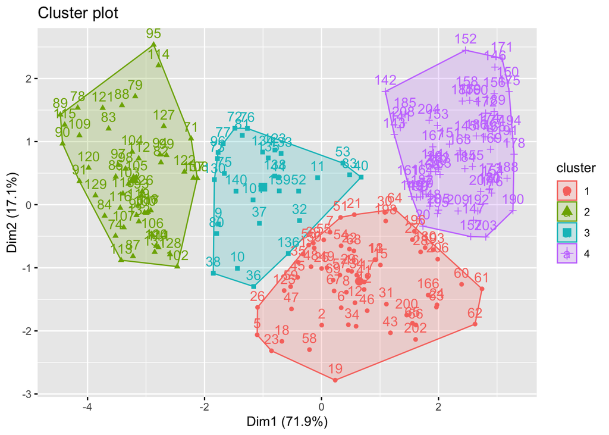

```r
fviz_cluster(km_model, data = data2)
```

## Elbow method

Using the Elbow method, the optimal number of clusters was determined by plotting the number of clusters (k) versus the total within the sum of squares. Figure 4 shows a steep decline in the total within the sum of squares between where k=1 and k=2, a less steep but still significant decline between k=2 and k=3, and after k=3, the total within the sum of squares levels off. According to the Elbow method, k=3 is the optimal number of clusters to use in the model, since the plot levels off after this point.

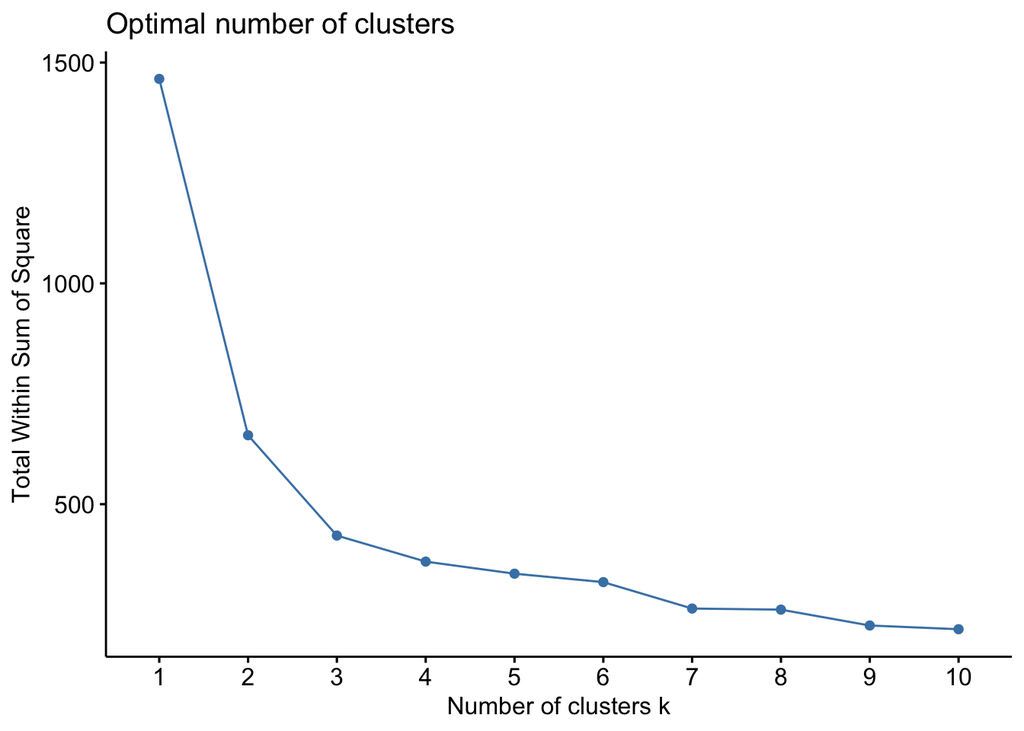

```r
fviz_nbclust(data2, kmeans, method = "wss")
```

## Model 2

The k-means method was repeated for k=3 to build another model (Model 2) to cluster the data. Model 2 contains 3 clusters with sizes of 71, 67, and 72. The within cluster sum of squares for each group were 144.5, 139.6, and 144.6. Dividing the distance between the sum of squares by the total sum of squares results in 70.7%, which is a lower explained variance than Model 1.

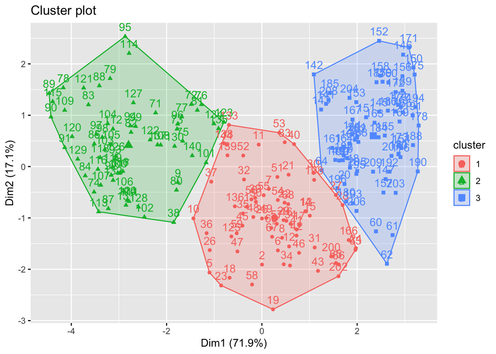

```r
# We will compute using k=3
km_model_k2<-kmeans(data2, centers=3, nstart=25)
fviz_cluster(km_model_k2, data = data2)
```

```r
# Cluster details of the data points
km_model_k2
```

```
## K-means clustering with 3 clusters of sizes 71, 67, 72
##
## Cluster means:
##         Area  Perimeter Compactness length_of_kernel width_of_kernel
## 1 -0.1407831 -0.1696372   0.4485346       -0.2571999     0.001643014
## 2  1.2536860  1.2589580   0.5591283        1.2349319     1.162075101
## 3 -1.0277967 -1.0042491  -0.9626050       -0.8955451    -1.082995635
##   asymmetry_coefficient length_of_kernel_groove
## 1           -0.66034079              -0.5844965
## 2           -0.04511157               1.2892273
## 3            0.69314821              -0.6233191
##
## Clustering vector:
##   [1] 1 1 1 1 1 1 1 1 2 1 1 1 1 1 1 1 1 1 1 3 1 1 1 1 1 1 1 1 1 1 1 1 1 1 1 1 1
##  [38] 2 1 1 1 1 1 1 1 1 1 1 1 1 1 1 1 1 1 1 1 1 1 3 3 3 1 3 1 1 1 1 1 3 2 2 2 2
##  [75] 2 2 2 2 2 2 2 2 2 2 2 2 2 2 2 2 2 2 2 2 2 2 2 2 2 2 2 2 2 2 2 2 2 2 2 2 2
## [112] 2 2 2 2 2 2 2 2 2 2 2 2 2 1 2 2 2 2 2 2 2 1 2 2 1 2 1 1 2 3 3 3 3 3 3 3 3
## [149] 3 3 3 3 3 3 3 3 3 3 3 3 3 3 3 3 3 1 3 3 3 3 3 3 3 3 3 3 3 3 3 3 3 3 3 3 3
## [186] 3 3 3 3 3 3 3 3 3 3 3 3 1 3 1 3 1 3 3 3 3 3 3 3 3
##
## Within cluster sum of squares by cluster:
## [1] 144.4586 139.5542 144.5954
##  (between_SS / total_SS =  70.7 %)
##
## Available components:
##
## [1] "cluster"      "centers"      "totss"        "withinss"     "tot.withinss"
## [6] "betweenss"    "size"         "iter"         "ifault"
```

```r
km_model_k2$cluster
```

```
##   [1] 1 1 1 1 1 1 1 1 2 1 1 1 1 1 1 1 1 1 1 3 1 1 1 1 1 1 1 1 1 1 1 1 1 1 1 1 1
##  [38] 2 1 1 1 1 1 1 1 1 1 1 1 1 1 1 1 1 1 1 1 1 1 3 3 3 1 3 1 1 1 1 1 3 2 2 2 2
##  [75] 2 2 2 2 2 2 2 2 2 2 2 2 2 2 2 2 2 2 2 2 2 2 2 2 2 2 2 2 2 2 2 2 2 2 2 2 2
## [112] 2 2 2 2 2 2 2 2 2 2 2 2 2 1 2 2 2 2 2 2 2 1 2 2 1 2 1 1 2 3 3 3 3 3 3 3 3
## [149] 3 3 3 3 3 3 3 3 3 3 3 3 3 3 3 3 3 1 3 3 3 3 3 3 3 3 3 3 3 3 3 3 3 3 3 3 3
## [186] 3 3 3 3 3 3 3 3 3 3 3 3 1 3 1 3 1 3 3 3 3 3 3 3 3
```

```r
km_model_k2$centers
```

```
##         Area  Perimeter Compactness length_of_kernel width_of_kernel
## 1 -0.1407831 -0.1696372   0.4485346       -0.2571999     0.001643014
## 2  1.2536860  1.2589580   0.5591283        1.2349319     1.162075101
## 3 -1.0277967 -1.0042491  -0.9626050       -0.8955451    -1.082995635
##   asymmetry_coefficient length_of_kernel_groove
## 1           -0.66034079              -0.5844965
## 2           -0.04511157               1.2892273
## 3            0.69314821              -0.6233191
```

## Kmeans clustering comparison

Model 2 created more evenly divided groups than Model 1, but Model 1 had the higher explained varience (74.7% compared to 70.7%). Model 1 has 4 clusters compared to Model 2’s 3 clusters, and adding clusters increases the explained variance. Model 2 is stronger because the groups are more evently divided, as we know should be the case from the documentation, and the explained variance is not significantly lower and is still at an acceptable level.

## Hierachical clustering

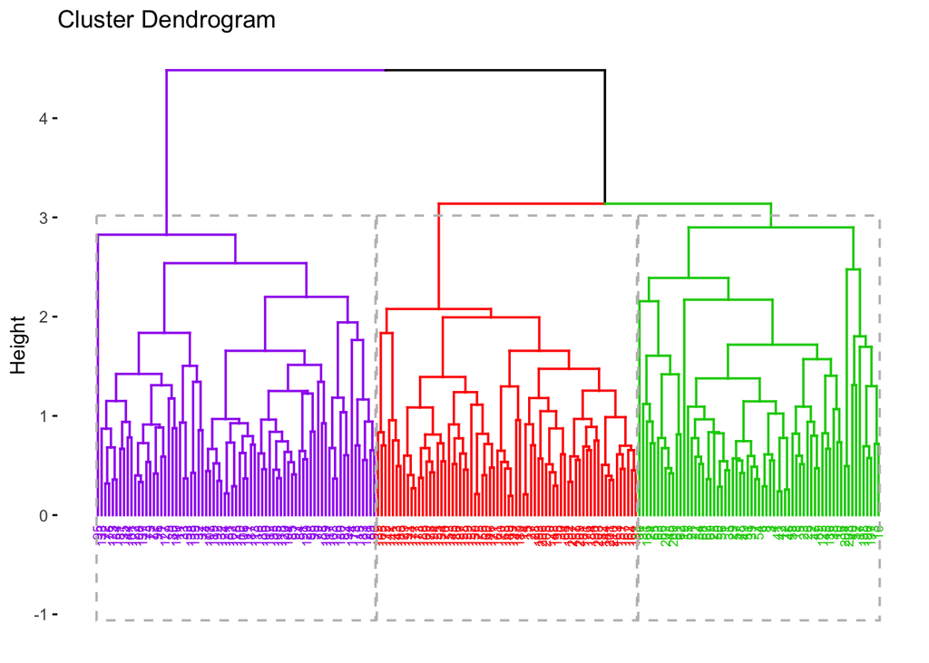

```r
dist_obs_seeds<-dist(data2, method="euclidean")
cluster_hier<-hclust(dist_obs_seeds,method="average")

require(factoextra)
fviz_dend(x = cluster_hier,
          rect = TRUE,
          cex = 0.5, lwd = 0.6,
          k = 3,
          k_colors = c("purple","red",
                       "green3"),
          rect_border = "gray",
          rect_fill = FALSE)
```

## Model 3.1

Complete linkage was used. The clusters were plotted using the fviz_dend function.

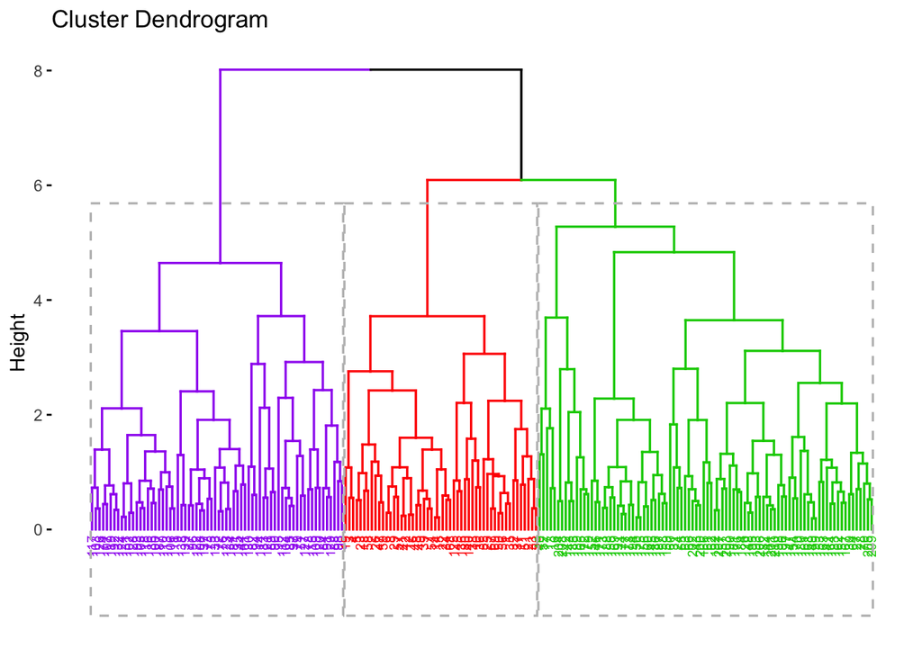

```r
dist_obs_seeds<-dist(data2, method="euclidean")
cluster_hier<-hclust(dist_obs_seeds,method="complete")

require(factoextra)
fviz_dend(x = cluster_hier,
          rect = TRUE,
          cex = 0.5, lwd = 0.6,
          k = 3,
          k_colors = c("purple","red",
                       "green3"),
          rect_border = "gray",
          rect_fill = FALSE)
```

## Hierarchial clustering comparison

The two dendrograms create similar models of clusters, although in Model 3, the groups are more evenly split and in Model 3.1, group 3 (green) is significantly larger. In Model 3, the cut height is 3, and in Model 3.1, the cut height is near 6, meaning there is higher dissimilarity between the clusters. This follows that the method used (complete linkage) uses the maximum distance between clusters.

## Interpretations and Recommendations

In this analysis, four models were created to cluster 210 seed samples into similar groups using measurements and calculations related to the seeds characteristics. The initial model created four clusters of sizes ranging from 30 to 65 and an explained variance of 74.7%. Using information from that model, the ideal number of clusters was identified as k=3, and a second model was created with 3 clusters. Model 2 was more uniform in size (groups ranging from 67 to 72), and the explained variance is 70.7%.

Looking at the visuals of the plots, Model 2 appears to be the better model because it creates three distinct groups that are mostly unique from each other. While the explained variance was smaller in Model 2, it was only 4 percentage points lower, which is marginal and not worth adding another cluster to the model. Two additional models were created using the hierarchical method, one model using average linkage and the other model using complete linkage. The two models are relatively similar to each other. The preferred model is Model 3 because the groups are more even in size, and using average linkage creates a model based on all the data points, not only the points farthest apart (as with complete linkage).

While the k-means and hierarchical methods created strong models at clustering seeds, we know they are not perfect models due to not creating equal groups of 70. (We know the data represents 70 samples of 3 types of seeds from the documentation accompanying the .txt file). Further tuning of the model is required to correctly cluster the data. This can be achieved by finding a different way of standardizing the data, eliminating variables that may not be helping the clustering, or further tuning the way the models are created.